# Auswertung der Top 250 Filme aus der IMDb

Timo Glaser

31 Oktober 2018

*Auswertung der Top 250 Filme aus der IMDb* ([Liste](https://www.imdb.com/chart/top?ref_=nv_mv_250))

## Einlesen der Datei (Tabelle)

```r
top250.t <- read.delim("250movies.txt", sep="\t", header=FALSE)
```

```r
nrow(top250.t)
```

```
[1] 250
```

```r
head(top250.t)
```

|  | V1 | V2 | V3 | V4 | V5 | V6 | V7 |
| --- | --- | --- | --- | --- | --- | --- | --- |
| 1 | ï»¿ï»¿1. | The Shawshank Redemption | 1994 | 9.2 | 12345678910 | NOT YET RELEASED | Seen |
| 2 | 2. | The Godfather | 1972 | 9.2 | 12345678910 | NOT YET RELEASED | Seen |
| 3 | 3. | The Godfather: Part II | 1974 | 9.0 | 12345678910 | NOT YET RELEASED | Seen |
| 4 | 4. | The Dark Knight | 2008 | 9.0 | 12345678910 | NOT YET RELEASED | Seen |
| 5 | 5. | 12 Angry Men | 1957 | 8.9 | 12345678910 | NOT YET RELEASED | Seen |
| 6 | 6. | Schindler's List | 1993 | 8.9 | 12345678910 | NOT YET RELEASED | Seen |

```r
tail(top250.t)
```

|  | V1 | V2 | V3 | V4 | V5 | V6 | V7 |
| --- | --- | --- | --- | --- | --- | --- | --- |
| 245 | 245. | Guardians of the Galaxy | 2014 | 8 | 12345678910 | NOT YET RELEASED | Seen |
| 246 | 246. | PK - Andere Sterne, Andere Sitten | 2014 | 8 | 12345678910 | NOT YET RELEASED | Seen |
| 247 | 247. | Pirates of the Caribbean: The Curse of the Black Pearl | 2003 | 8 | 12345678910 | NOT YET RELEASED | Seen |
| 248 | 248. | Castle in the Sky | 1986 | 8 | 12345678910 | NOT YET RELEASED | Seen |
| 249 | 249. | The Best Years of Our Lives | 1946 | 8 | 12345678910 | NOT YET RELEASED | Seen |
| 250 | 250. | Fanny and Alexander | 1982 | 8 | 12345678910 | NOT YET RELEASED | Seen |

```r
?head
# mit ? vor einer Funktion, wird die Hilfefunktion aufgerufen.
# (Manchmal ist der Hilfetext hilfreich, oftmals ist Google besser)
```

> Aufgabe 1: lassen Sie sich die ersten 10 Zeilen der Tabelle anzeigen.

> Aufgabe 2: lassen Sie sich die letzten 10 Zeilen der Tabelle anzeigen.

```r
tail(top250.t, n=10)
```

|  | V1 | V2 | V3 | V4 | V5 | V6 | V7 |
| --- | --- | --- | --- | --- | --- | --- | --- |
| 241 | 241. | A Wednesday | 2008 | 8 | 12345678910 | NOT YET RELEASED | Seen |
| 242 | 242. | Paris, Texas | 1984 | 8 | 12345678910 | NOT YET RELEASED | Seen |
| 243 | 243. | Die Taschendiebin | 2016 | 8 | 12345678910 | NOT YET RELEASED | Seen |
| 244 | 244. | The Bourne Ultimatum | 2007 | 8 | 12345678910 | NOT YET RELEASED | Seen |
| 245 | 245. | Guardians of the Galaxy | 2014 | 8 | 12345678910 | NOT YET RELEASED | Seen |
| 246 | 246. | PK - Andere Sterne, Andere Sitten | 2014 | 8 | 12345678910 | NOT YET RELEASED | Seen |
| 247 | 247. | Pirates of the Caribbean: The Curse of the Black Pearl | 2003 | 8 | 12345678910 | NOT YET RELEASED | Seen |
| 248 | 248. | Castle in the Sky | 1986 | 8 | 12345678910 | NOT YET RELEASED | Seen |
| 249 | 249. | The Best Years of Our Lives | 1946 | 8 | 12345678910 | NOT YET RELEASED | Seen |
| 250 | 250. | Fanny and Alexander | 1982 | 8 | 12345678910 | NOT YET RELEASED | Seen |

```r
head(top250.t, n=10)
```

|  | V1 | V2 | V3 | V4 | V5 | V6 | V7 |
| --- | --- | --- | --- | --- | --- | --- | --- |
| 1 | ï»¿ï»¿1. | The Shawshank Redemption | 1994 | 9.2 | 12345678910 | NOT YET RELEASED | Seen |
| 2 | 2. | The Godfather | 1972 | 9.2 | 12345678910 | NOT YET RELEASED | Seen |
| 3 | 3. | The Godfather: Part II | 1974 | 9.0 | 12345678910 | NOT YET RELEASED | Seen |
| 4 | 4. | The Dark Knight | 2008 | 9.0 | 12345678910 | NOT YET RELEASED | Seen |
| 5 | 5. | 12 Angry Men | 1957 | 8.9 | 12345678910 | NOT YET RELEASED | Seen |
| 6 | 6. | Schindler's List | 1993 | 8.9 | 12345678910 | NOT YET RELEASED | Seen |
| 7 | 7. | The Lord of the Rings: The Return of the King | 2003 | 8.9 | 12345678910 | NOT YET RELEASED | Seen |
| 8 | 8. | Pulp Fiction | 1994 | 8.9 | 12345678910 | NOT YET RELEASED | Seen |
| 9 | 9. | The Good, the Bad and the Ugly | 1966 | 8.8 | 12345678910 | NOT YET RELEASED | Seen |
| 10 | 10. | Fight Club | 1999 | 8.8 | 12345678910 | NOT YET RELEASED | Seen |

```r
nrow(top250.t)
```

```
[1] 250
```

## Tabelle bearbeiten

### überflüssige Spalten entfernen

```r
# einzelne Zeilen anzeigen lassen
top250.t[4,]
```

|  | V1 | V2 | V3 | V4 | V5 | V6 | V7 |
| --- | --- | --- | --- | --- | --- | --- | --- |
| 4 | 4. | The Dark Knight | 2008 | 9 | 12345678910 | NOT YET RELEASED | Seen |

```r
# einzelne Zelle anzeigen lassen
top250.t[20,2]
```

```
[1] City of God
250 Levels: 12 Angry Men 12 Years a Slave 2001: A Space Odyssey 3 Idiots A Beautiful Mind A Clockwork Orange A Separation A Star Is Born A Wednesday ... Your Name.
```

```r
# einzelne Spalte anzeigen lassen
top250.t[,3]
```

```
  [1] 1994 1972 1974 2008 1957 1993 2003 1994 1966 1999 2001 1994 1980 2010 2002 1975 1990 1999 1954 2002 1995 1977 1991 1946 1997 1995 2001 1998 1994 1999 2014
 [32] 1960 1998 1931 1968 1942 1936 2011 2002 2006 1991 1985 2014 1954 1981 2000 1994 2006 1979 2000 2018 1979 1940 1988 1988 1950 2006 1964 1957 1980 2012 2008
 [63] 1997 1957 1999 2012 2003 2017 1986 1984 1981 1941 1995 1958 1959 1992 1983 2016 1931 2016 2000 1984 2007 1962 2004 1971 2001 2009 1944 1968 1995 1976 1952
 [94] 1987 2009 1962 1948 1921 1973 2010 1997 2012 2000 1975 1983 1965 1997 1960 1927 2011 1989 1950 2009 1950 1961 2005 1959 1992 2004 1948 1988 1995 1952 1980
[125] 2010 1963 2005 1997 2006 1949 1974 1988 1985 2004 1961 2009 1925 1957 2017 2001 1954 1998 1995 1957 2015 2015 1980 1939 2013 2005 2011 1982 1926 1957 1954
[156] 1996 2007 2007 1999 1939 1982 1996 2008 1978 2003 1985 1924 1998 2003 2010 1967 1940 1953 2018 2016 2009 1927 2014 2010 2014 1993 2007 1996 1979 1934 1993
[187] 1986 2014 1986 1998 1976 1979 2004 1959 1966 2003 2013 1966 1953 2004 2006 1928 2013 2015 1995 1959 2015 2009 2017 2013 2000 1987 1984 2002 1969 2011 1976
[218] 1975 2001 1940 1941 1955 2001 1962 1984 1982 1989 1995 1993 2017 2016 1957 1939 1975 2011 2000 1973 2012 2013 2004 2008 1984 2016 2007 2014 2014 2003 1986
[249] 1946 1982
```

```r
# um mehrere Zeilen auszuwählen, wird der Bereich angegeben
top250.t[1:4,]
```

|  | V1 | V2 | V3 | V4 | V5 | V6 | V7 |
| --- | --- | --- | --- | --- | --- | --- | --- |
| 1 | ï»¿ï»¿1. | The Shawshank Redemption | 1994 | 9.2 | 12345678910 | NOT YET RELEASED | Seen |
| 2 | 2. | The Godfather | 1972 | 9.2 | 12345678910 | NOT YET RELEASED | Seen |
| 3 | 3. | The Godfather: Part II | 1974 | 9.0 | 12345678910 | NOT YET RELEASED | Seen |
| 4 | 4. | The Dark Knight | 2008 | 9.0 | 12345678910 | NOT YET RELEASED | Seen |

```r
# um mehrere Spalten auszuwählen, wird der Bereich angegeben
top250.t[,2:3]
```

| V2 | V3 |
| --- | --- |
| The Shawshank Redemption | 1994 |
| The Godfather | 1972 |
| The Godfather: Part II | 1974 |
| The Dark Knight | 2008 |
| 12 Angry Men | 1957 |
| Schindler's List | 1993 |
| The Lord of the Rings: The Return of the King | 2003 |
| Pulp Fiction | 1994 |
| The Good, the Bad and the Ugly | 1966 |
| Fight Club | 1999 |

[output cut: 240 more lines]

Um Spalten zu löschen, können die gewünschten Spaltennummern ausgewählt werden, die erhalten bleiben sollen und mit dem gleichen Variablen-Namen gespeichert werden.

> Aufgabe: erstellen Sie eine neue Tabelle (mit dem gleichen Tabellen-Namen top250.t), der nur die Spalten 1-4 enthält.  
> Zur Überprüfung, lassen Sie sich die Zeilen 6-9 der neuen Tabelle anzeigen.

```r
top250.t <- top250.t[,1:4]
```

```r
top250.t[6:9,]
```

|  | V1 | V2 | V3 | V4 |
| --- | --- | --- | --- | --- |
| 6 | 6. | Schindler's List | 1993 | 8.9 |
| 7 | 7. | The Lord of the Rings: The Return of the King | 2003 | 8.9 |
| 8 | 8. | Pulp Fiction | 1994 | 8.9 |
| 9 | 9. | The Good, the Bad and the Ugly | 1966 | 8.8 |

### Spaltennamen hinzufügen

```r
colnames(top250.t) <- c("Rang", "Titel", "Jahr", "Bewertung")
```

> Aufgabe: Überprüfen Sie, ob die Tabelle jetzt Spaltennamen hat (ohne sich die ganze Tabelle anzeigen zu lassen.)

```r
head(top250.t)
```

|  | Rang | Titel | Jahr | Bewertung |
| --- | --- | --- | --- | --- |
| 1 | ï»¿ï»¿1. | The Shawshank Redemption | 1994 | 9.2 |
| 2 | 2. | The Godfather | 1972 | 9.2 |
| 3 | 3. | The Godfather: Part II | 1974 | 9.0 |
| 4 | 4. | The Dark Knight | 2008 | 9.0 |
| 5 | 5. | 12 Angry Men | 1957 | 8.9 |
| 6 | 6. | Schindler's List | 1993 | 8.9 |

## Visualisieren

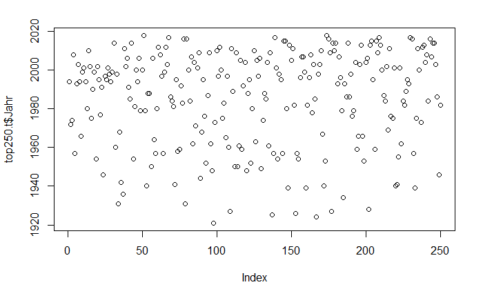

```r
plot(top250.t$Jahr)
```

Verteilung zeigt, dass zwar mehr Filme ab ca. den 90ern in den Top 250 sind als ältere Filme, dass es aber keinen Zusammenhang zwischen Alter des Filmes und der Beliebtheit gibt.

### Filme nach Jahrzehnten gruppieren

```r
Tabelle <- table(top250.t$Jahr) #table-Funktion summiert nach gleichen Werten
print(Tabelle)
```

```
1921 1924 1925 1926 1927 1928 1931 1934 1936 1939 1940 1941 1942 1944 1946 1948 1949 1950 1952 1953 1954 1955 1957 1958 1959 1960 1961 1962 1963 1964 1965 1966
   1    1    1    1    2    1    2    1    1    3    3    2    1    1    2    2    1    3    2    2    4    1    7    1    4    2    2    3    1    1    1    3
1967 1968 1969 1971 1972 1973 1974 1975 1976 1977 1978 1979 1980 1981 1982 1983 1984 1985 1986 1987 1988 1989 1990 1991 1992 1993 1994 1995 1996 1997 1998 1999
   1    2    1    1    1    2    2    4    3    1    1    4    4    2    4    2    5    3    4    2    4    2    1    2    2    4    5    8    3    5    5    5
2000 2001 2002 2003 2004 2005 2006 2007 2008 2009 2010 2011 2012 2013 2014 2015 2016 2017 2018
   6    6    4    6    6    3    5    5    4    6    5    5    4    5    7    4    5    4    2
```

> Aufgabe: Können Sie die table-Funktion so umschreiben und erweitern, dass sie nicht die einzelnen Jahre, sondern Jahrzehnte zusammengefasst haben?

```r
TabelleJahrzehnt <- table(trunc(top250.t$Jahr/10)) # mathematische Operation und trunc-Funktion!
print(TabelleJahrzehnt)
```

```
192 193 194 195 196 197 198 199 200 201
  7   7  12  24  17  19  32  40  51  41
```

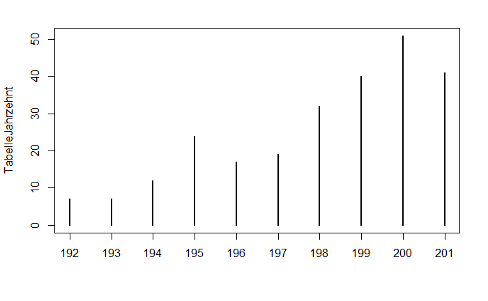

```r
#visualisiert sieht das so aus:
plot(TabelleJahrzehnt)
```

Statt **192, 193, …** soll am Ende **1920er, 1930er, …** stehen. Dazu gehen wir nochmal einen Schritt zurück und erstellen eine Variable mit allen Jahreszahlen, die zu Jahrzehnten umgeschrieben werden (aber noch keine Häufigkeitstabelle!):

```r
dek <- trunc(top250.t$Jahr/10)
print(dek)
```

```
  [1] 199 197 197 200 195 199 200 199 196 199 200 199 198 201 200 197 199 199 195 200 199 197 199 194 199 199 200 199 199 199 201 196 199 193 196 194 193 201 200
 [40] 200 199 198 201 195 198 200 199 200 197 200 201 197 194 198 198 195 200 196 195 198 201 200 199 195 199 201 200 201 198 198 198 194 199 195 195 199 198 201
 [79] 193 201 200 198 200 196 200 197 200 200 194 196 199 197 195 198 200 196 194 192 197 201 199 201 200 197 198 196 199 196 192 201 198 195 200 195 196 200 195
[118] 199 200 194 198 199 195 198 201 196 200 199 200 194 197 198 198 200 196 200 192 195 201 200 195 199 199 195 201 201 198 193 201 200 201 198 192 195 195 199
[157] 200 200 199 193 198 199 200 197 200 198 192 199 200 201 196 194 195 201 201 200 192 201 201 201 199 200 199 197 193 199 198 201 198 199 197 197 200 195 196
[196] 200 201 196 195 200 200 192 201 201 199 195 201 200 201 201 200 198 198 200 196 201 197 197 200 194 194 195 200 196 198 198 198 199 199 201 201 195 193 197
[235] 201 200 197 201 201 200 200 198 201 200 201 201 200 198 194 198
```

```r
# um aus 199, 197, 200 => 1990, 1970, 2000,... zu machen:
dek <- 10*dek
print(dek)
```

```
  [1] 1990 1970 1970 2000 1950 1990 2000 1990 1960 1990 2000 1990 1980 2010 2000 1970 1990 1990 1950 2000 1990 1970 1990 1940 1990 1990 2000 1990 1990 1990 2010
 [32] 1960 1990 1930 1960 1940 1930 2010 2000 2000 1990 1980 2010 1950 1980 2000 1990 2000 1970 2000 2010 1970 1940 1980 1980 1950 2000 1960 1950 1980 2010 2000
 [63] 1990 1950 1990 2010 2000 2010 1980 1980 1980 1940 1990 1950 1950 1990 1980 2010 1930 2010 2000 1980 2000 1960 2000 1970 2000 2000 1940 1960 1990 1970 1950
 [94] 1980 2000 1960 1940 1920 1970 2010 1990 2010 2000 1970 1980 1960 1990 1960 1920 2010 1980 1950 2000 1950 1960 2000 1950 1990 2000 1940 1980 1990 1950 1980
[125] 2010 1960 2000 1990 2000 1940 1970 1980 1980 2000 1960 2000 1920 1950 2010 2000 1950 1990 1990 1950 2010 2010 1980 1930 2010 2000 2010 1980 1920 1950 1950
[156] 1990 2000 2000 1990 1930 1980 1990 2000 1970 2000 1980 1920 1990 2000 2010 1960 1940 1950 2010 2010 2000 1920 2010 2010 2010 1990 2000 1990 1970 1930 1990
[187] 1980 2010 1980 1990 1970 1970 2000 1950 1960 2000 2010 1960 1950 2000 2000 1920 2010 2010 1990 1950 2010 2000 2010 2010 2000 1980 1980 2000 1960 2010 1970
[218] 1970 2000 1940 1940 1950 2000 1960 1980 1980 1980 1990 1990 2010 2010 1950 1930 1970 2010 2000 1970 2010 2010 2000 2000 1980 2010 2000 2010 2010 2000 1980
[249] 1940 1980
```

Bislang haben wir noch Zahlen; jetzt machen wir aus den Zahlen Text, so dass aus **1990, 1970, …** => **1990er, 1970er, …** wird.

```r
dek <- paste(dek,"er", sep="")
# hat 3 Parameter: die beiden Werte, die zusammen gefügt werden sollen und den Trenner
print(dek)
```

```
  [1] "1990er" "1970er" "1970er" "2000er" "1950er" "1990er" "2000er" "1990er" "1960er" "1990er" "2000er" "1990er" "1980er" "2010er" "2000er" "1970er" "1990er"
 [18] "1990er" "1950er" "2000er" "1990er" "1970er" "1990er" "1940er" "1990er" "1990er" "2000er" "1990er" "1990er" "1990er" "2010er" "1960er" "1990er" "1930er"
 [35] "1960er" "1940er" "1930er" "2010er" "2000er" "2000er" "1990er" "1980er" "2010er" "1950er" "1980er" "2000er" "1990er" "2000er" "1970er" "2000er" "2010er"
 [52] "1970er" "1940er" "1980er" "1980er" "1950er" "2000er" "1960er" "1950er" "1980er" "2010er" "2000er" "1990er" "1950er" "1990er" "2010er" "2000er" "2010er"
 [69] "1980er" "1980er" "1980er" "1940er" "1990er" "1950er" "1950er" "1990er" "1980er" "2010er" "1930er" "2010er" "2000er" "1980er" "2000er" "1960er" "2000er"
 [86] "1970er" "2000er" "2000er" "1940er" "1960er" "1990er" "1970er" "1950er" "1980er" "2000er" "1960er" "1940er" "1920er" "1970er" "2010er" "1990er" "2010er"
[103] "2000er" "1970er" "1980er" "1960er" "1990er" "1960er" "1920er" "2010er" "1980er" "1950er" "2000er" "1950er" "1960er" "2000er" "1950er" "1990er" "2000er"
[120] "1940er" "1980er" "1990er" "1950er" "1980er" "2010er" "1960er" "2000er" "1990er" "2000er" "1940er" "1970er" "1980er" "1980er" "2000er" "1960er" "2000er"
[137] "1920er" "1950er" "2010er" "2000er" "1950er" "1990er" "1990er" "1950er" "2010er" "2010er" "1980er" "1930er" "2010er" "2000er" "2010er" "1980er" "1920er"
[154] "1950er" "1950er" "1990er" "2000er" "2000er" "1990er" "1930er" "1980er" "1990er" "2000er" "1970er" "2000er" "1980er" "1920er" "1990er" "2000er" "2010er"
[171] "1960er" "1940er" "1950er" "2010er" "2010er" "2000er" "1920er" "2010er" "2010er" "2010er" "1990er" "2000er" "1990er" "1970er" "1930er" "1990er" "1980er"
[188] "2010er" "1980er" "1990er" "1970er" "1970er" "2000er" "1950er" "1960er" "2000er" "2010er" "1960er" "1950er" "2000er" "2000er" "1920er" "2010er" "2010er"
[205] "1990er" "1950er" "2010er" "2000er" "2010er" "2010er" "2000er" "1980er" "1980er" "2000er" "1960er" "2010er" "1970er" "1970er" "2000er" "1940er" "1940er"
[222] "1950er" "2000er" "1960er" "1980er" "1980er" "1980er" "1990er" "1990er" "2010er" "2010er" "1950er" "1930er" "1970er" "2010er" "2000er" "1970er" "2010er"
[239] "2010er" "2000er" "2000er" "1980er" "2010er" "2000er" "2010er" "2010er" "2000er" "1980er" "1940er" "1980er"
```

```r
# Und jetzt fügen wir diese Information noch als zusätzliche Spalte zu unserer Tabelle hinzu
top250.t$Dekade <- dek
```

```r
head(top250.t)
```

|  | Rang | Titel | Jahr | Bewertung | Dekade |
| --- | --- | --- | --- | --- | --- |
| 1 | ï»¿ï»¿1. | The Shawshank Redemption | 1994 | 9.2 | 1990er |
| 2 | 2. | The Godfather | 1972 | 9.2 | 1970er |
| 3 | 3. | The Godfather: Part II | 1974 | 9.0 | 1970er |
| 4 | 4. | The Dark Knight | 2008 | 9.0 | 2000er |
| 5 | 5. | 12 Angry Men | 1957 | 8.9 | 1950er |
| 6 | 6. | Schindler's List | 1993 | 8.9 | 1990er |

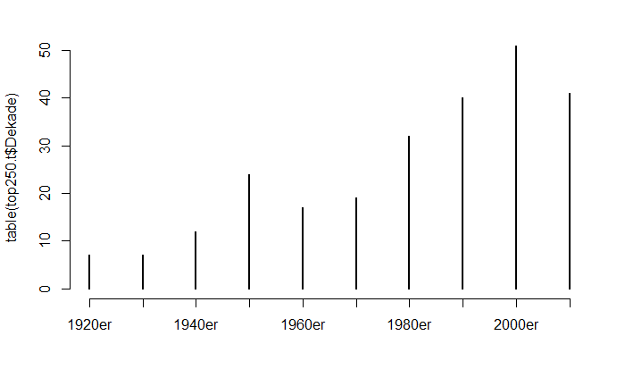

```r
plot(table(top250.t$Dekade))
```

```r
#Die Hilfefunktion zum Plot finden Sie:
?plot
```

> Aufgabe: Machen Sie den Plot etwas schöner, indem Sie die Linienart und Farbe ändern, eine Überschrift hinzufügen und die Bezeichnung der y-Achse ändern

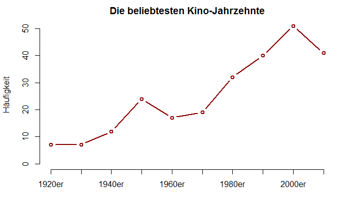

```r
plot(table(top250.t$Dekade), type="b", col="dark red",
main="Die beliebtesten Kino-Jahrzehnte", ylab="Häufigkeit")
```